# Creating a Linear Regression Model to Help Predict the Best Sales Price for Homes in Ames Iowa

```r
bc5 <- boxcox(lm(SalePrice~X1st.Flr.SF, data=dfnew))
```

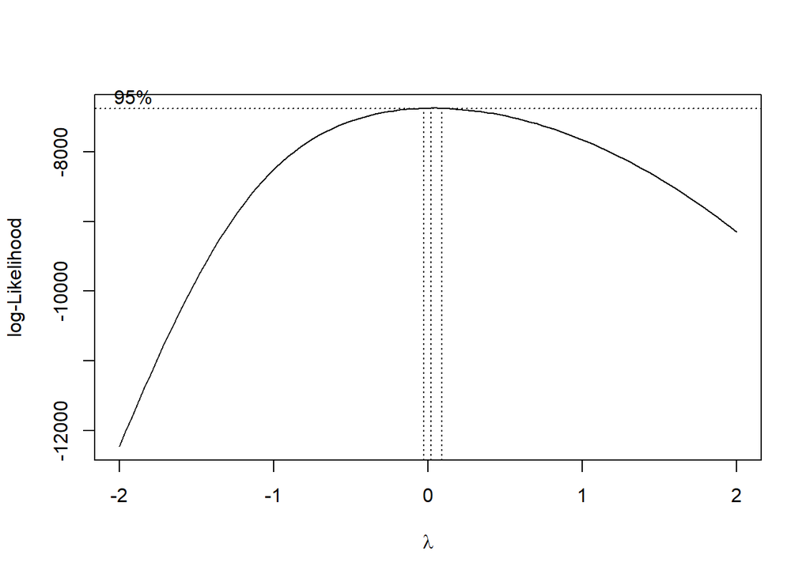

```r
bc6 <- boxcox(lm(SalePrice~Total.Bsmt.SF, data=dfnew))
```

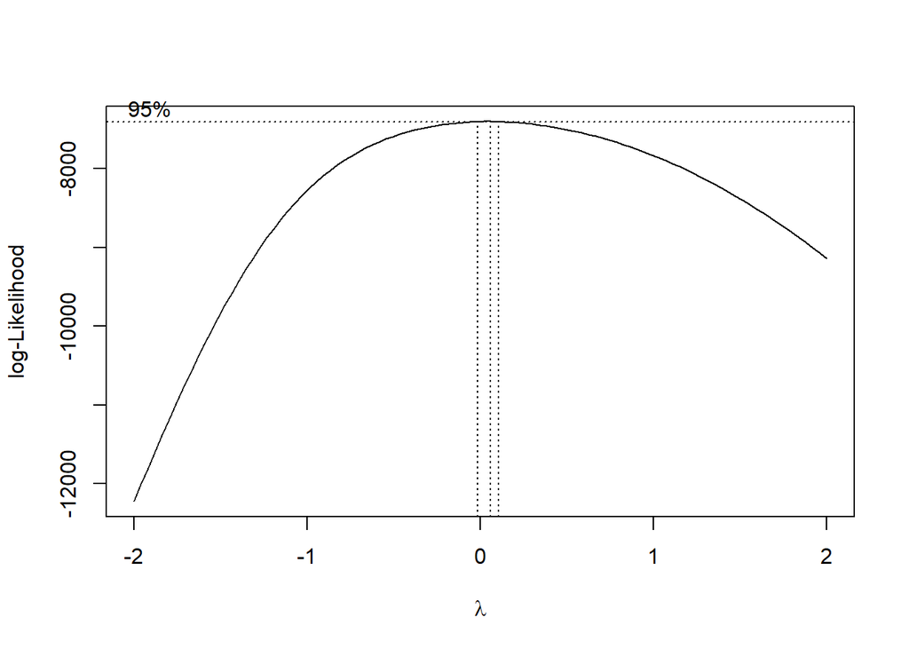

```r
bc7 <- boxcox(lm(SalePrice~Full.Bath, data=dfnew))
```

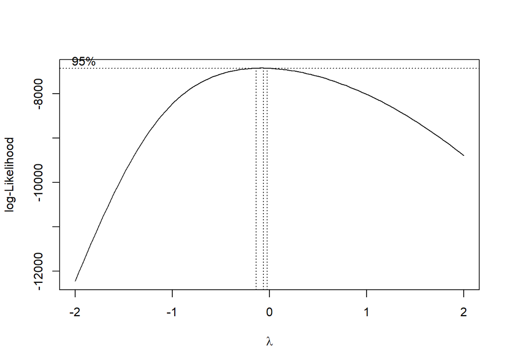

```r
bc8 <- boxcox(lm(SalePrice~Year.Built, data=dfnew))
```

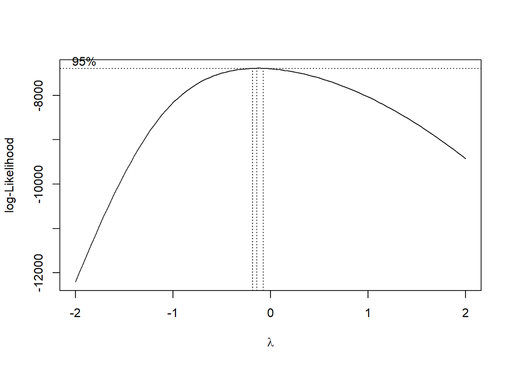

```r
optimal_lambda1 <- bc1$x[which(bc1$y == max(bc1$y))]
round(optimal_lambda1, 2)
```

```
## [1] 0.06
```

```r
optimal_lambda2 <- bc2$x[which(bc2$y == max(bc2$y))]
round(optimal_lambda2, 2)
```

```
## [1] 0.06
```

```r
optimal_lambda3 <- bc3$x[which(bc3$y == max(bc3$y))]
round(optimal_lambda3, 2)
```

```
## [1] 0.02
```

```r
optimal_lambda4 <- bc4$x[which(bc4$y == max(bc4$y))]
round(optimal_lambda4, 2)
```

```
## [1] 0.06
```

```r
optimal_lambda5 <- bc5$x[which(bc5$y == max(bc5$y))]
round(optimal_lambda5, 2)
```

```
## [1] 0.02
```

```r
optimal_lambda6 <- bc6$x[which(bc6$y == max(bc6$y))]
round(optimal_lambda6, 2)
```

```
## [1] 0.06
```

```r
optimal_lambda7 <- bc7$x[which(bc7$y == max(bc7$y))]
round(optimal_lambda7, 2)
```

```
## [1] -0.06
```

```r
optimal_lambda8 <- bc8$x[which(bc8$y == max(bc8$y))]
round(optimal_lambda8, 2)
```

```
## [1] -0.14
```

All of 8 numerical variables are qualified to be transformed to log. But we need to take a look over their new relationships with SalePrice to decide which one should be used in log transformation.

## 3.6. New relationships with SalePrice after Box-Cox transformation

- log(Overall.Qual) with log(SalePrice)

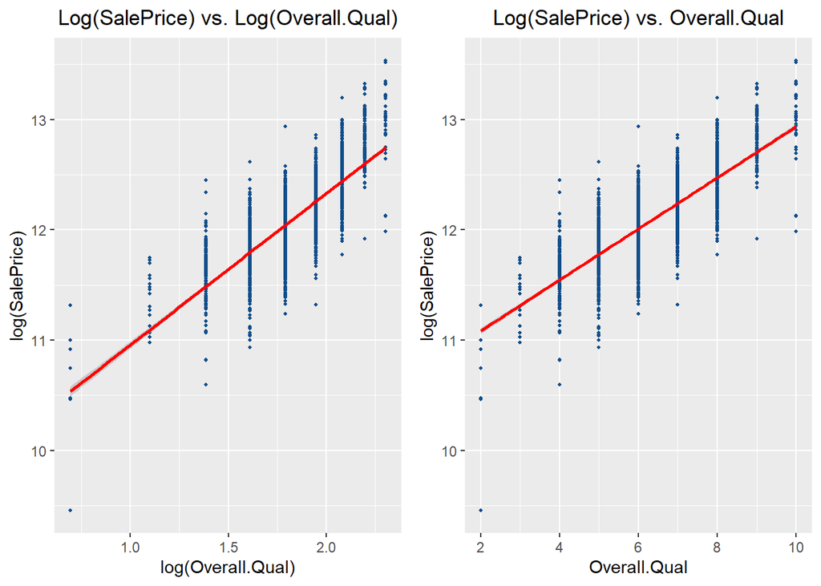

```r
g1 <- ggplot(dfnew, aes(x=log(Overall.Qual), y=log(SalePrice))) +
  geom_point(color="dodgerblue4",size=0.7) +
  labs(title="Log(SalePrice) vs. Log(Overall.Qual)") +
  geom_smooth(formula=y~x,method=lm, color="red") +
  theme(plot.title=element_text(hjust=0.5))

g2 <- ggplot(dfnew, aes(x=Overall.Qual, y=log(SalePrice))) +
  geom_point(color="dodgerblue4", size=0.7) +
  labs(title="Log(SalePrice) vs. Overall.Qual") +
  geom_smooth(formula=y~x,method=lm, color="red") +
  theme(plot.title=element_text(hjust=0.5))

ggarrange(g1, g2, ncol=2,nrow=1)
```

- log(Gr.Liv.Area) with log(SalePrice)

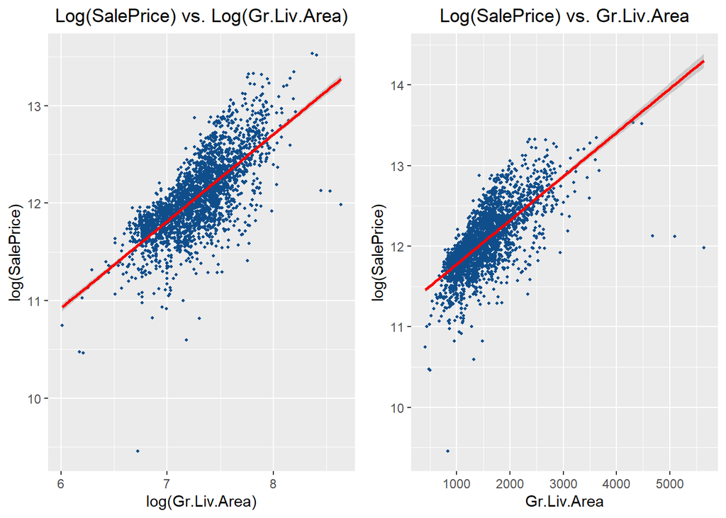

```r
g1 <- ggplot(dfnew, aes(x=log(Gr.Liv.Area), y=log(SalePrice))) +
  geom_point(color="dodgerblue4",size=0.7) +
  labs(title="Log(SalePrice) vs. Log(Gr.Liv.Area)") +
  geom_smooth(formula=y~x,method=lm, color="red") +
  theme(plot.title=element_text(hjust=0.5))

g2 <- ggplot(dfnew, aes(x=Gr.Liv.Area, y=log(SalePrice))) +
  geom_point(color="dodgerblue4", size=0.7) +
  labs(title="Log(SalePrice) vs. Gr.Liv.Area") +
  geom_smooth(formula=y~x,method=lm, color="red") +
  theme(plot.title=element_text(hjust=0.5))

ggarrange(g1, g2, ncol=2,nrow=1)
```

- log(X1st.Flr.SF) with log(SalePrice)

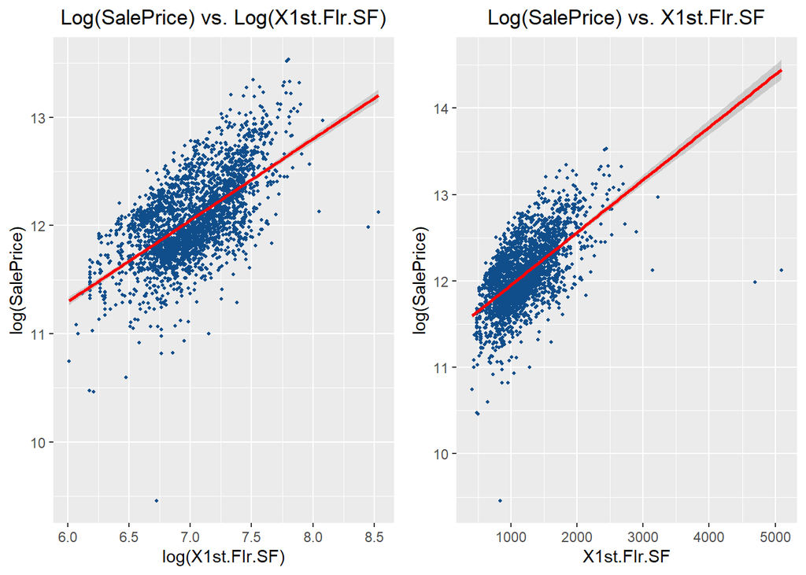

```r
g1 <- ggplot(dfnew, aes(x=log(X1st.Flr.SF), y=log(SalePrice))) +
  geom_point(color="dodgerblue4",size=0.7) +
  labs(title="Log(SalePrice) vs. Log(X1st.Flr.SF)") +
  geom_smooth(formula=y~x,method=lm, color="red") +
  theme(plot.title=element_text(hjust=0.5))

g2 <- ggplot(dfnew, aes(x=X1st.Flr.SF, y=log(SalePrice))) +
  geom_point(color="dodgerblue4", size=0.7) +
  labs(title="Log(SalePrice) vs. X1st.Flr.SF") +
  geom_smooth(formula=y~x,method=lm, color="red") +
  theme(plot.title=element_text(hjust=0.5))

ggarrange(g1, g2, ncol=2,nrow=1)
```

- log(Year.Built) with log(SalePrice)

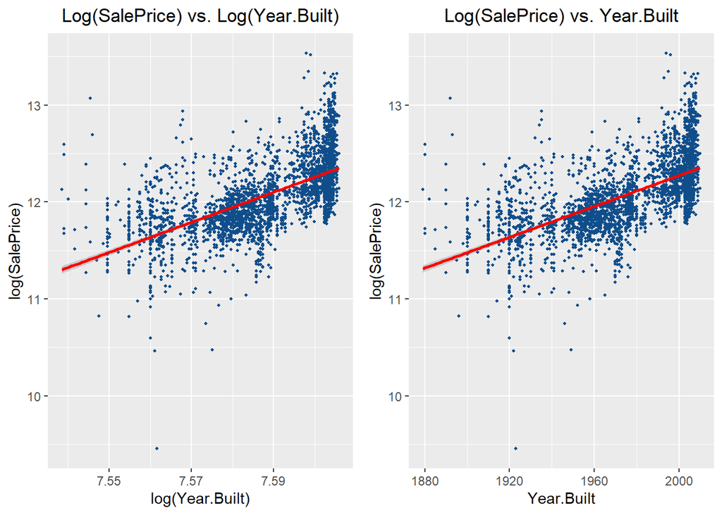

```r
g1 <- ggplot(dfnew, aes(x=log(Year.Built), y=log(SalePrice))) +
  geom_point(color="dodgerblue4",size=0.7) +
  labs(title="Log(SalePrice) vs. Log(Year.Built)") +
  geom_smooth(formula=y~x,method=lm, color="red") +
  theme(plot.title=element_text(hjust=0.5))

g2 <- ggplot(dfnew, aes(x=Year.Built, y=log(SalePrice))) +
  geom_point(color="dodgerblue4", size=0.7) +
  labs(title="Log(SalePrice) vs. Year.Built") +
  geom_smooth(formula=y~x,method=lm, color="red") +
  theme(plot.title=element_text(hjust=0.5))

ggarrange(g1, g2, ncol=2,nrow=1)
```

- log(Garage.Cars) with log(SalePrice)

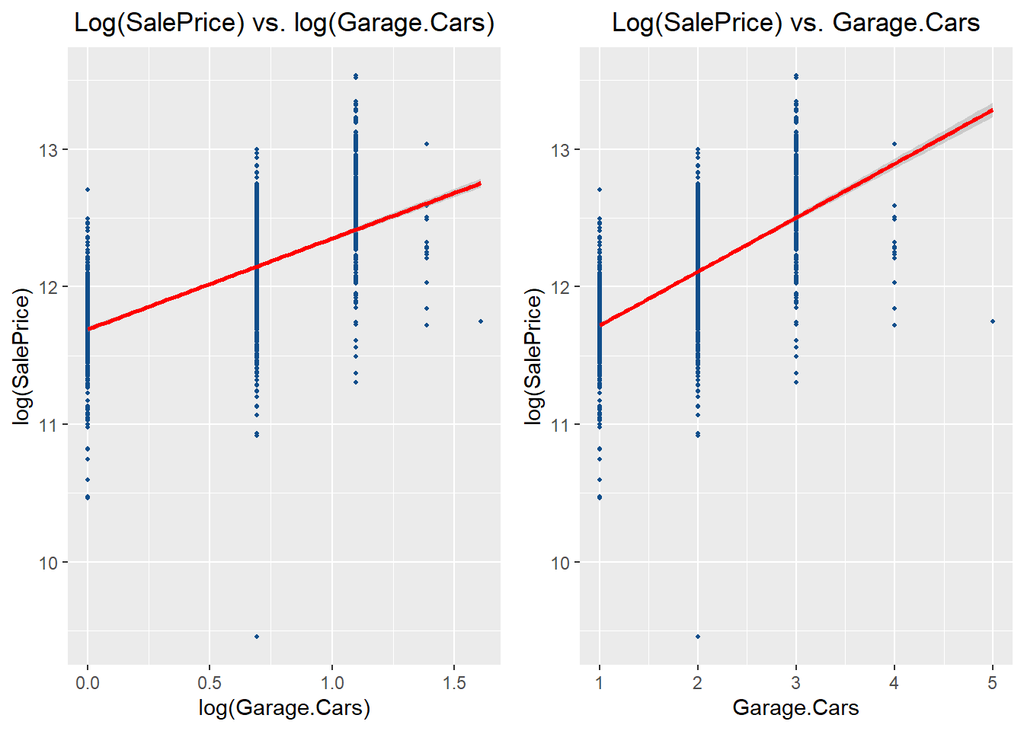

```r
g1 <- ggplot(dfnew, aes(x=log(Garage.Cars), y=log(SalePrice))) +
  geom_point(color="dodgerblue4",size=0.7) +
  labs(title="Log(SalePrice) vs. log(Garage.Cars)") +
  geom_smooth(formula=y~x,method=lm, color="red") +
  theme(plot.title=element_text(hjust=0.5))

g2 <- ggplot(dfnew, aes(x=Garage.Cars, y=log(SalePrice))) +
  geom_point(color="dodgerblue4", size=0.7) +
  labs(title="Log(SalePrice) vs. Garage.Cars") +
  geom_smooth(formula=y~x,method=lm, color="red") +
  theme(plot.title=element_text(hjust=0.5))

ggarrange(g1, g2, ncol=2,nrow=1)
```

- log(Garage.Area) with log(SalePrice)

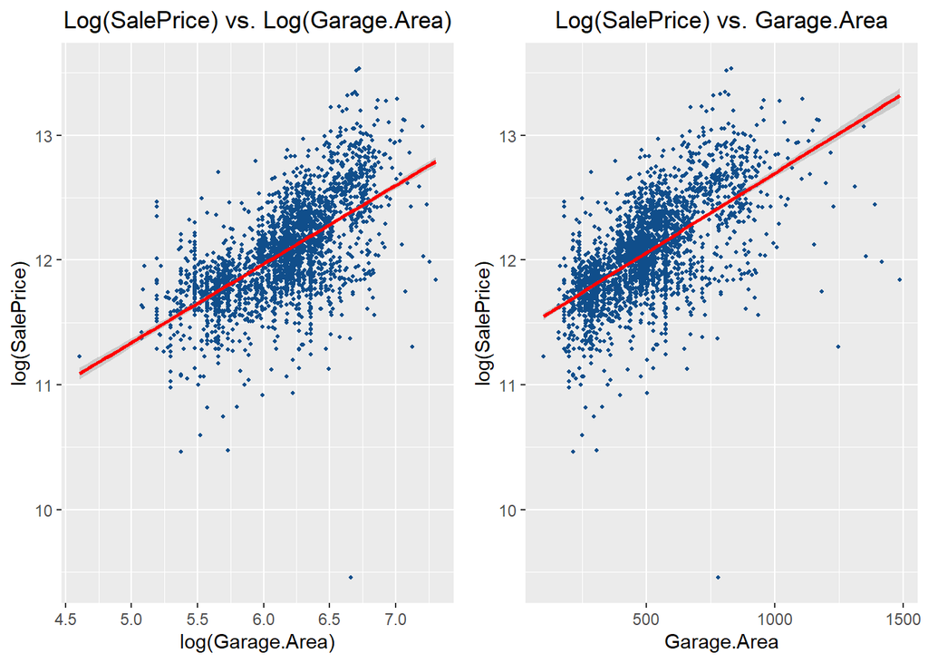

```r
g1 <- ggplot(dfnew, aes(x=log(Garage.Area), y=log(SalePrice))) +
  geom_point(color="dodgerblue4",size=0.7) +
  labs(title="Log(SalePrice) vs. Log(Garage.Area)") +
  geom_smooth(formula=y~x,method=lm, color="red") +
  theme(plot.title=element_text(hjust=0.5))

g2 <- ggplot(dfnew, aes(x=Garage.Area, y=log(SalePrice))) +
  geom_point(color="dodgerblue4", size=0.7) +
  labs(title="Log(SalePrice) vs. Garage.Area") +
  geom_smooth(formula=y~x,method=lm, color="red") +
  theme(plot.title=element_text(hjust=0.5))

ggarrange(g1, g2, ncol=2,nrow=1)
```

- log(Total.Bsmt.SF) with log(SalePrice)

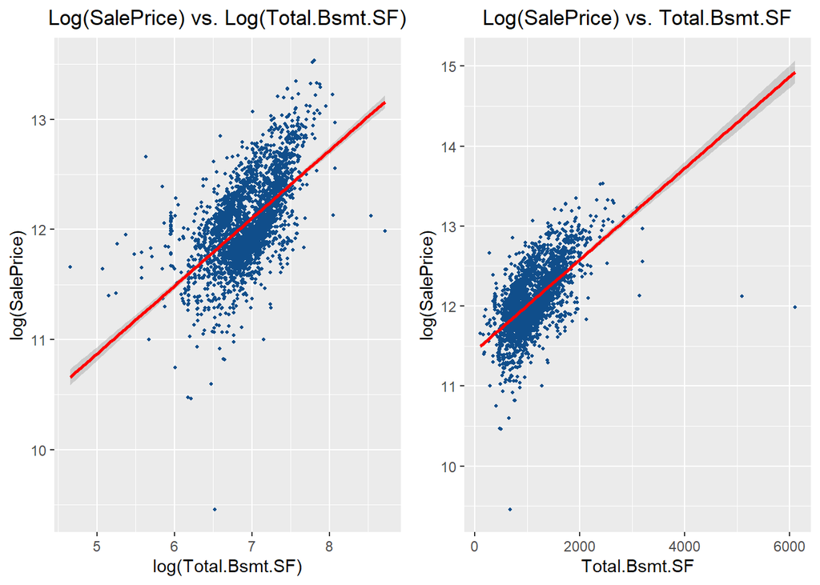

```r
g1 <- ggplot(dfnew, aes(x=log(Total.Bsmt.SF), y=log(SalePrice))) +
  geom_point(color="dodgerblue4",size=0.7) +
  labs(title="Log(SalePrice) vs. Log(Total.Bsmt.SF)") +
  geom_smooth(formula=y~x,method=lm, color="red") +
  theme(plot.title=element_text(hjust=0.5))

g2 <- ggplot(dfnew, aes(x=Total.Bsmt.SF, y=log(SalePrice))) +
  geom_point(color="dodgerblue4", size=0.7) +
  labs(title="Log(SalePrice) vs. Total.Bsmt.SF") +
  geom_smooth(formula=y~x,method=lm, color="red") +
  theme(plot.title=element_text(hjust=0.5))

ggarrange(g1, g2, ncol=2,nrow=1)
```

- log(Full.Bath) with log(SalePrice)

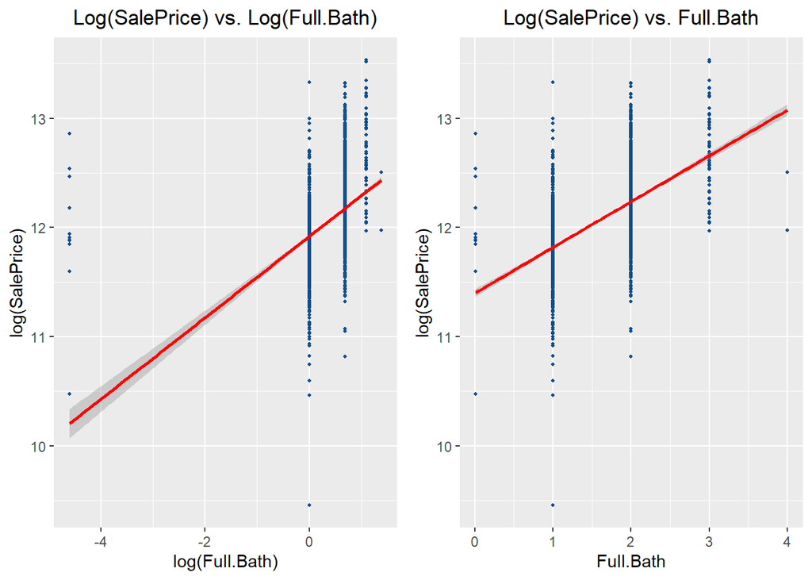

```r
g1 <- ggplot(dfnew, aes(x=log(Full.Bath), y=log(SalePrice))) +
  geom_point(color="dodgerblue4",size=0.7) +
  labs(title="Log(SalePrice) vs. Log(Full.Bath)") +
  geom_smooth(formula=y~x,method=lm, color="red") +
  theme(plot.title=element_text(hjust=0.5))

g2 <- ggplot(dfnew, aes(x=Full.Bath, y=log(SalePrice))) +
  geom_point(color="dodgerblue4", size=0.7) +
  labs(title="Log(SalePrice) vs. Full.Bath") +
  geom_smooth(formula=y~x,method=lm, color="red") +
  theme(plot.title=element_text(hjust=0.5))

ggarrange(g1, g2, ncol=2,nrow=1)
```

As a result from this step, we decided to use log transformation for 4 independent numerical variables: Gr.Liv.Area, Garage.Area, X1st.Flr.SF, Total.Bsmt.SF.

## 3.7. Colinearity

Regarding the Garage.Cars variable, we saw the colinearity between this variable and Garage.Area.

```r
# Investigate the relationship between Garage.Area and Garage.Cars
cor(dfnew$Garage.Area,dfnew$Garage.Cars)
```

```
## [1] 0.8461278
```

```r
cor(dfnew$Bsmt.Qual_Excellent,dfnew$Total.Bsmt.SF)
```

```
## [1] 0.4417961
```

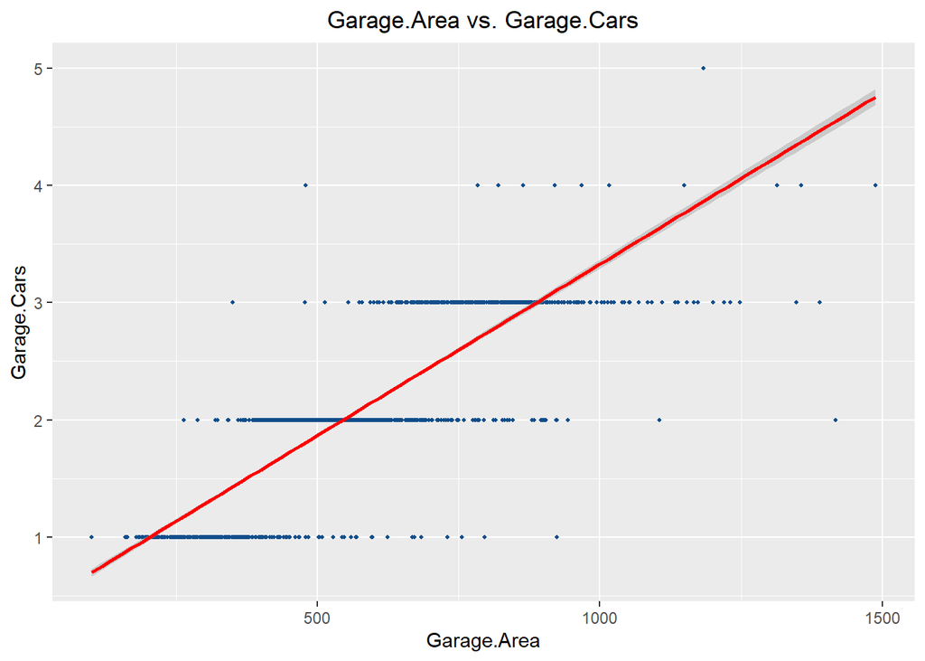

```r
g1 <- ggplot(dfnew, aes(x=Garage.Area, y=Garage.Cars)) +
  geom_point(color="dodgerblue4",size=0.7) +
  labs(title="Garage.Area vs. Garage.Cars") +
  geom_smooth(formula=y~x,method=lm, color="red") +
  theme(plot.title=element_text(hjust=0.5))
g1
```

-> Remove the Garage.Cars from the analysis

# 4. Modeling

## 4.1. Modeling with top 9 variables

- Create training and teting dataset from dfnew

```r
#Create Evaluation Sets
set.seed(1)
trainIndexes = sample(nrow(df),2000)

#Creates training and test set from observations
training = dfnew[trainIndexes,]
testing = dfnew[-trainIndexes,]
```

- Creat the first model including 7 numerical variables and 2 categorical variables:

```r
SalePrice_model1 <- lm(log(SalePrice) ~ Overall.Qual + log(Gr.Liv.Area) + log(Garage.Area) + log(X1st.Flr.SF) + log(Total.Bsmt.SF) +  Full.Bath + Year.Built + Kitchen.Qual_Excellent + Bsmt.Qual_Excellent, data = dfnew)
summary(SalePrice_model1)
```

```
##
## Call:
## lm(formula = log(SalePrice) ~ Overall.Qual + log(Gr.Liv.Area) +
##     log(Garage.Area) + log(X1st.Flr.SF) + log(Total.Bsmt.SF) +
##     Full.Bath + Year.Built + Kitchen.Qual_Excellent + Bsmt.Qual_Excellent,
##     data = dfnew)
##
## Residuals:
##      Min       1Q   Median       3Q      Max
## -1.81391 -0.07214  0.00698  0.08576  0.51822
##
## Coefficients:
##                          Estimate Std. Error t value             Pr(>|t|)
## (Intercept)             1.2630115  0.3076368   4.106    0.000041548729774 ***
## Overall.Qual            0.0933659  0.0036497  25.582 < 0.0000000000000002 ***
## log(Gr.Liv.Area)        0.4169537  0.0153687  27.130 < 0.0000000000000002 ***
## log(Garage.Area)        0.0730494  0.0105426   6.929    0.000000000005292 ***
## log(X1st.Flr.SF)        0.1336279  0.0184769   7.232    0.000000000000618 ***
## log(Total.Bsmt.SF)      0.0648504  0.0152669   4.248    0.000022328029899 ***
## Full.Bath              -0.0164522  0.0080849  -2.035                0.042 *
## Year.Built              0.0027175  0.0001464  18.556 < 0.0000000000000002 ***
## Kitchen.Qual_Excellent  0.0775726  0.0146830   5.283    0.000000137199443 ***
## Bsmt.Qual_Excellent     0.0667357  0.0135507   4.925    0.000000895462898 ***
## ---
## Signif. codes:  0 '***' 0.001 '**' 0.01 '*' 0.05 '.' 0.1 ' ' 1
##
## Residual standard error: 0.1562 on 2673 degrees of freedom
## Multiple R-squared:  0.8353, Adjusted R-squared:  0.8347
## F-statistic:  1506 on 9 and 2673 DF,  p-value: < 0.00000000000000022
```

```r
SalePrice_model2 <- lm(log(SalePrice) ~ Overall.Qual + log(Gr.Liv.Area) + log(Garage.Area) + log(X1st.Flr.SF) + log(Total.Bsmt.SF) +  Year.Built + Kitchen.Qual_Excellent + Bsmt.Qual_Excellent, data = dfnew)
summary(SalePrice_model2)
```

```
##
## Call:
## lm(formula = log(SalePrice) ~ Overall.Qual + log(Gr.Liv.Area) +
##     log(Garage.Area) + log(X1st.Flr.SF) + log(Total.Bsmt.SF) +
##     Year.Built + Kitchen.Qual_Excellent + Bsmt.Qual_Excellent,
##     data = dfnew)
##
## Residuals:
##      Min       1Q   Median       3Q      Max
## -1.81833 -0.07130  0.00785  0.08578  0.52211
##
## Coefficients:
##                        Estimate Std. Error t value             Pr(>|t|)
## (Intercept)            1.538295   0.276459   5.564    0.000000028935587 ***
## Overall.Qual           0.092937   0.003646  25.492 < 0.0000000000000002 ***
## log(Gr.Liv.Area)       0.401038   0.013237  30.296 < 0.0000000000000002 ***
## log(Garage.Area)       0.071687   0.010528   6.810    0.000000000012048 ***
## log(X1st.Flr.SF)       0.135351   0.018468   7.329    0.000000000000306 ***
## log(Total.Bsmt.SF)     0.064842   0.015276   4.245    0.000022631616879 ***
## Year.Built             0.002623   0.000139  18.876 < 0.0000000000000002 ***
## Kitchen.Qual_Excellent 0.079446   0.014663   5.418    0.000000065558660 ***
## Bsmt.Qual_Excellent    0.067464   0.013554   4.977    0.000000685148615 ***
## ---
## Signif. codes:  0 '***' 0.001 '**' 0.01 '*' 0.05 '.' 0.1 ' ' 1
##
## Residual standard error: 0.1563 on 2674 degrees of freedom
## Multiple R-squared:  0.835,  Adjusted R-squared:  0.8346
## F-statistic:  1692 on 8 and 2674 DF,  p-value: < 0.00000000000000022
```

- Try to investigate the interaction between log(Total.Bsmt.SF) and Bsmt.Qual:

```r
SalePrice_model3 <- lm(log(SalePrice) ~ Overall.Qual + log(Gr.Liv.Area) + log(Garage.Area) + log(X1st.Flr.SF) + log(Total.Bsmt.SF) +  Year.Built + Bsmt.Qual + log(Total.Bsmt.SF)*Bsmt.Qual, data = df)
summary(SalePrice_model3)
```

```
##
## Call:
## lm(formula = log(SalePrice) ~ Overall.Qual + log(Gr.Liv.Area) +
##     log(Garage.Area) + log(X1st.Flr.SF) + log(Total.Bsmt.SF) +
##     Year.Built + Bsmt.Qual + log(Total.Bsmt.SF) * Bsmt.Qual,
##     data = df)
##
## Residuals:
##      Min       1Q   Median       3Q      Max
## -1.75473 -0.07623  0.00881  0.09005  0.50983
##
## Coefficients:
##                                       Estimate Std. Error t value
## (Intercept)                          2.8738349  0.4381620   6.559
## Overall.Qual                         0.0937878  0.0037279  25.158
## log(Gr.Liv.Area)                     0.3986026  0.0134809  29.568
## log(Garage.Area)                     0.0715694  0.0105468   6.786
## log(X1st.Flr.SF)                     0.1310742  0.0187252   7.000
## log(Total.Bsmt.SF)                   0.0236615  0.0368717   0.642
## Year.Built                           0.0021846  0.0001759  12.422
## Bsmt.QualGood                       -0.6569770  0.2616792  -2.511
## Bsmt.QualFair                        0.9555701  0.4325374   2.209
## Bsmt.QualTypical                    -0.4039974  0.2690686  -1.501
## Bsmt.QualPoor                       -0.1147148  1.7096362  -0.067
## log(Total.Bsmt.SF):Bsmt.QualGood     0.0766275  0.0357855   2.141
## log(Total.Bsmt.SF):Bsmt.QualFair    -0.1839420  0.0635727  -2.893
## log(Total.Bsmt.SF):Bsmt.QualTypical  0.0362350  0.0370476   0.978
## log(Total.Bsmt.SF):Bsmt.QualPoor    -0.0251689  0.3078122  -0.082
##                                                 Pr(>|t|)
## (Intercept)                             0.00000000006489 ***
## Overall.Qual                        < 0.0000000000000002 ***
## log(Gr.Liv.Area)                    < 0.0000000000000002 ***
## log(Garage.Area)                        0.00000000001416 ***
## log(X1st.Flr.SF)                        0.00000000000323 ***
## log(Total.Bsmt.SF)                               0.52111
## Year.Built                          < 0.0000000000000002 ***
## Bsmt.QualGood                                    0.01211 *
## Bsmt.QualFair                                    0.02724 *
## Bsmt.QualTypical                                 0.13335
## Bsmt.QualPoor                                    0.94651
## log(Total.Bsmt.SF):Bsmt.QualGood                 0.03234 *
## log(Total.Bsmt.SF):Bsmt.QualFair                 0.00384 **
## log(Total.Bsmt.SF):Bsmt.QualTypical              0.32813
## log(Total.Bsmt.SF):Bsmt.QualPoor                 0.93484
## ---
## Signif. codes:  0 '***' 0.001 '**' 0.01 '*' 0.05 '.' 0.1 ' ' 1
##
## Residual standard error: 0.1558 on 2668 degrees of freedom
## Multiple R-squared:  0.8365, Adjusted R-squared:  0.8356
## F-statistic: 974.9 on 14 and 2668 DF,  p-value: < 0.00000000000000022
```

```r
summary(SalePrice_model2)
```

```
##
## Call:
## lm(formula = log(SalePrice) ~ Overall.Qual + log(Gr.Liv.Area) +
##     log(Garage.Area) + log(X1st.Flr.SF) + log(Total.Bsmt.SF) +
##     Year.Built + Kitchen.Qual_Excellent + Bsmt.Qual_Excellent,
##     data = dfnew)
##
## Residuals:
##      Min       1Q   Median       3Q      Max
## -1.81833 -0.07130  0.00785  0.08578  0.52211
##
## Coefficients:
##                        Estimate Std. Error t value             Pr(>|t|)
## (Intercept)            1.538295   0.276459   5.564    0.000000028935587 ***
## Overall.Qual           0.092937   0.003646  25.492 < 0.0000000000000002 ***
## log(Gr.Liv.Area)       0.401038   0.013237  30.296 < 0.0000000000000002 ***
## log(Garage.Area)       0.071687   0.010528   6.810    0.000000000012048 ***
## log(X1st.Flr.SF)       0.135351   0.018468   7.329    0.000000000000306 ***
## log(Total.Bsmt.SF)     0.064842   0.015276   4.245    0.000022631616879 ***
## Year.Built             0.002623   0.000139  18.876 < 0.0000000000000002 ***
## Kitchen.Qual_Excellent 0.079446   0.014663   5.418    0.000000065558660 ***
## Bsmt.Qual_Excellent    0.067464   0.013554   4.977    0.000000685148615 ***
## ---
## Signif. codes:  0 '***' 0.001 '**' 0.01 '*' 0.05 '.' 0.1 ' ' 1
##
## Residual standard error: 0.1563 on 2674 degrees of freedom
## Multiple R-squared:  0.835,  Adjusted R-squared:  0.8346
## F-statistic:  1692 on 8 and 2674 DF,  p-value: < 0.00000000000000022
```

- Create a confidence interval for the model coefficients

```r
confint(SalePrice_model2, conf.level=0.95)
```

```
##                              2.5 %      97.5 %
## (Intercept)            0.996200118 2.080389290
## Overall.Qual           0.085788216 0.100085562
## log(Gr.Liv.Area)       0.375081163 0.426994172
## log(Garage.Area)       0.051044369 0.092330192
## log(X1st.Flr.SF)       0.099137579 0.171565002
## log(Total.Bsmt.SF)     0.034888172 0.094795535
## Year.Built             0.002350419 0.002895358
## Kitchen.Qual_Excellent 0.050694386 0.108197096
## Bsmt.Qual_Excellent    0.040886859 0.094041254
```

- Check the diagnostic plots for the model

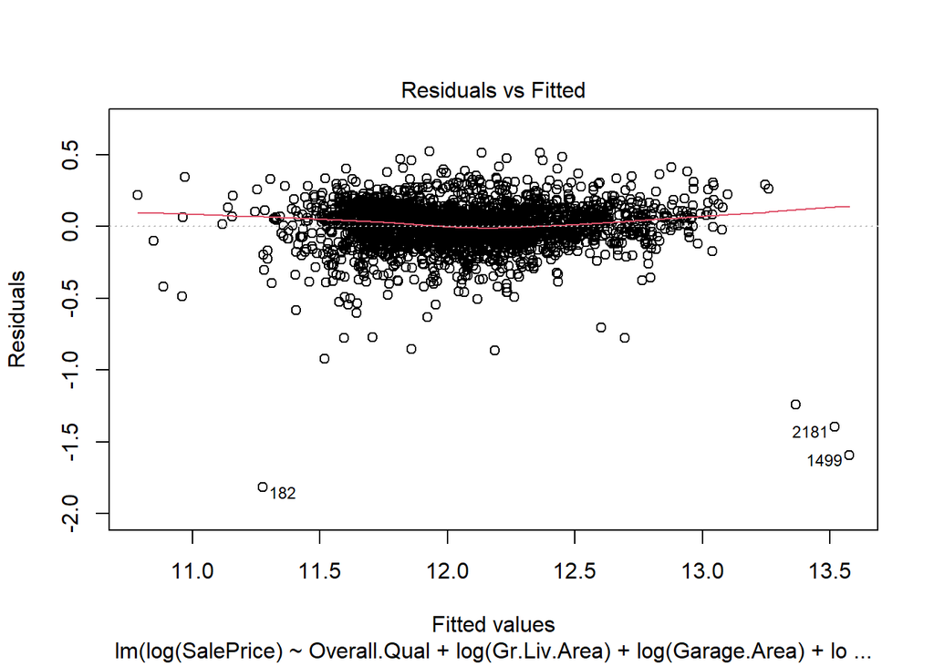

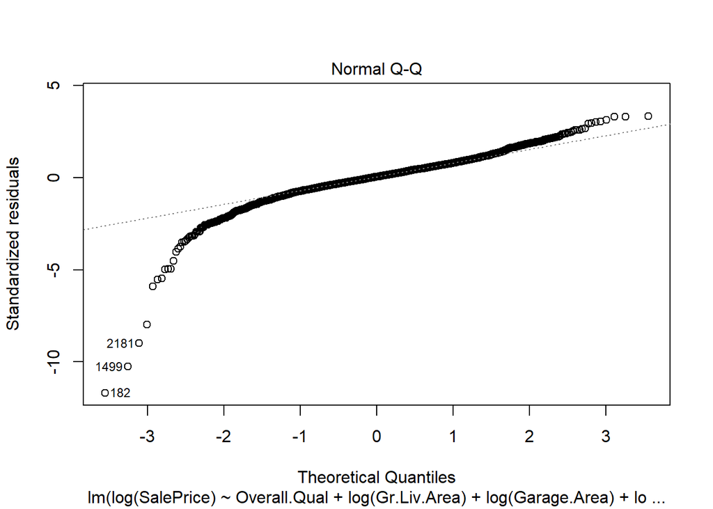

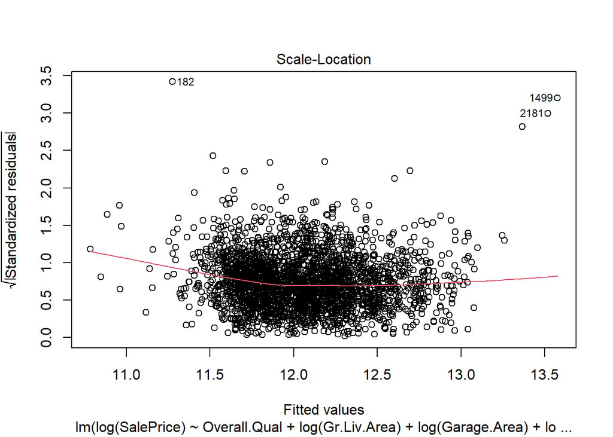

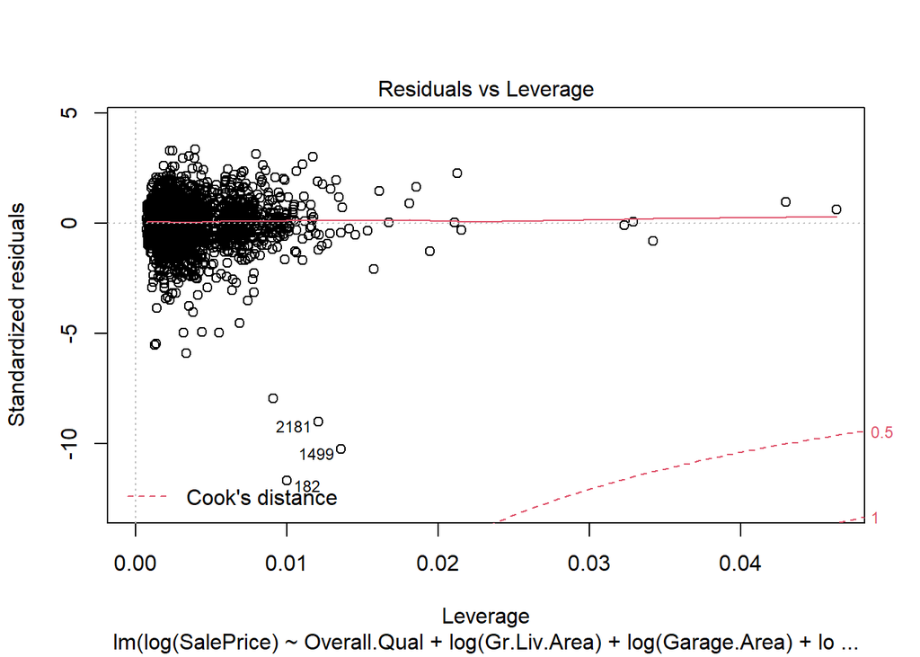

```r
plot(SalePrice_model2)
```

## 4.2. Model with full variables

- Create training and testing datasets
- Create Evaluation Sets

```r
dffull <- read.csv("dfnew.csv",
                     stringsAsFactors = FALSE, na.strings = c("NA", ""))
```

```r
set.seed(1)
trainIndexes = sample(nrow(dfnew),2000)

#Creates training and test set from observations
traindat = dffull[trainIndexes,]
testdat = dffull[-trainIndexes,]
```

```r
# Create a linear regression model
#Fit a linear regression model (to establish a familiar baseline)
model <- lm(SalePrice ~ . , traindat)

summary(model)
```

```
##
## Call:
## lm(formula = SalePrice ~ ., data = traindat)
##
## Residuals:
##     Min      1Q  Median      3Q     Max
## -335198  -10964    -381    9634  215975
##
## Coefficients: (49 not defined because of singularities)
##                             Estimate    Std. Error t value             Pr(>|t|)
## (Intercept)            10927990.4616 10556737.0157   1.035             0.300733
## X                            -7.8449        8.3456  -0.940             0.347345
## Lot.Frontage                -60.9247       38.5074  -1.582             0.113794
## Lot.Area                      0.5425        0.1154   4.699     0.00000281580629
## Overall.Qual               8712.4721      995.8945   8.748 < 0.0000000000000002
## Overall.Cond               4892.8300      877.2617   5.577     0.00000002822270
## Year.Built                  214.8070       88.3231   2.432             0.015113
## Year.Remod.Add               39.1170       55.5757   0.704             0.481620
## Mas.Vnr.Area                 20.1609        5.3785   3.748             0.000184
## BsmtFin.SF.1                  2.4275        4.6106   0.527             0.598603
## BsmtFin.SF.2                  8.8263        7.7521   1.139             0.255042
## Bsmt.Unf.SF                  -4.7963        4.3774  -1.096             0.273364
## Total.Bsmt.SF                     NA            NA      NA                   NA
## X1st.Flr.SF                  50.6497        5.1157   9.901 < 0.0000000000000002
## X2nd.Flr.SF                  58.6095        5.4288  10.796 < 0.0000000000000002
## Low.Qual.Fin.SF              44.5265       16.3528   2.723             0.006536
## Gr.Liv.Area                       NA            NA      NA                   NA
## Bsmt.Full.Bath             3538.9799     1894.4684   1.868             0.061920
## Bsmt.Half.Bath            -1637.6260     2741.8163  -0.597             0.550399
## Full.Bath                  4402.5227     2175.5712   2.024             0.043161
## Half.Bath                  5228.6717     2066.2631   2.530             0.011477
## Bedroom.AbvGr             -1175.4564     1376.2223  -0.854             0.393156
## Kitchen.AbvGr             -7940.0531     8357.7535  -0.950             0.342232
## TotRms.AbvGrd               146.1886      896.0424   0.163             0.870420
## Fireplaces                 4492.8333     1465.5949   3.066             0.002206
## Garage.Yr.Blt               -22.6457       61.1715  -0.370             0.711278
## Garage.Cars               10647.1840     2146.1332   4.961     0.00000076876320
## Garage.Area                  -1.5551        7.4764  -0.208             0.835257
## Wood.Deck.SF                 15.8180        5.5888   2.830             0.004704
## Open.Porch.SF               -13.4936       10.9483  -1.232             0.217934
```

[output cut: 550 more lines]

```
## Sale.Type_ConLI
## Sale.Type_CWD
## Sale.Type_VWD
## Sale.Condition_Normal  .
## Sale.Condition_Partial
## Sale.Condition_Family
## Sale.Condition_Abnorml *
## Sale.Condition_Alloca
## Sale.Condition_AdjLand
## ---
## Signif. codes:  0 '***' 0.001 '**' 0.01 '*' 0.05 '.' 0.1 ' ' 1
##
## Residual standard error: 26400 on 1755 degrees of freedom
## Multiple R-squared:  0.903,  Adjusted R-squared:  0.8895
## F-statistic: 66.95 on 244 and 1755 DF,  p-value: < 0.00000000000000022
```

```r
#Compute mean absolute error of model on train set
trainMAE <- mean(abs(model$residuals)) # 15081.7
trainMAE
```

```
## [1] 15087.01
```

```r
#Calculate predictions for each observation in test set
predictY <- predict(model, testdat)

#Compute model residuals on the test set
testerrors <- testdat$SalePrice - predictY

#Compute mean absolute error of model on test set
testMAE <- mean(abs(testerrors)) #17257.71
testMAE
```

```
## [1] 17060.62
```

```r
#Compute R^2
SSE <- sum((testdat$SalePrice- predictY)^2)
SST <- sum((testdat$SalePrice - mean(traindat$SalePrice))^2)
R_Square <- 1-(SSE/SST)
R_Square# 0.9049922
```

```
## [1] 0.8958246
```

```r
# back to new model
traindat = dffull[trainIndexes,]
#The rest of the observations are set aside for test
testdat = dffull[-trainIndexes,]

model <- lm(SalePrice ~ . , traindat)

prevtrainMAE = trainMAE
for (i in 1:ncol(traindat)){
  # Create a linear regression model
  varimportance = data.frame(pvalue=coef(summary(model))[,4])
  varimportance$Predictor <- rownames(varimportance)
  #drop intercept
  varimportance = varimportance[2:nrow(varimportance),]
  #sort on pvalue
  varimportance = varimportance[order(-varimportance$pvalue),]
  print(nrow(varimportance))
  print(varimportance[1,1])
  if (varimportance[1,1]<.05){
    break
  }
  #drop highest p-value
  varimportance = varimportance[2:nrow(varimportance),]
  #store x variable names for use in lm()
  newxvalues = varimportance$Predictor
  #Fit a linear regression model
  model <- lm(SalePrice ~ . , traindat[,c("SalePrice",newxvalues)])

  #Compute mean absolute error of model on train set
  newtrainMAE <- mean(abs(model$residuals))
}
```

```
## [1] 244
## [1] 0.9977677
## [1] 243
## [1] 0.9904243
## [1] 242
## [1] 0.9882855
## [1] 241
## [1] 0.9884851
## [1] 240
## [1] 0.9838508
## [1] 239
## [1] 0.9711138
## [1] 238
## [1] 0.9694182
## [1] 237
```

[output cut: 311 more lines]

```r
summary(model)
```

```
##
## Call:
## lm(formula = SalePrice ~ ., data = traindat[, c("SalePrice",
##     newxvalues)])
##
## Residuals:
##     Min      1Q  Median      3Q     Max
## -346624  -11358     -65   10254  246914
##
## Coefficients:
##                             Estimate    Std. Error t value             Pr(>|t|)
## (Intercept)            15778214.9505  6697982.2249   2.356             0.018590
## Lot.Frontage                -72.3190       34.3695  -2.104             0.035494
## Mas.Vnr.Type_BrkFace      12434.1775     6306.4079   1.972             0.048790
## Kitchen.Qual_Typical      -3223.4928     1639.0229  -1.967             0.049360
## Garage.Type_Attchd         3341.4565     1582.3620   2.112             0.034842
## Sale.Condition_Normal     -4658.0877     2166.8540  -2.150             0.031704
## Mas.Vnr.Type_Stone        14468.9754     6628.7935   2.183             0.029175
## Low.Qual.Fin.SF              30.7597       14.3516   2.143             0.032214
## Land.Slope_Mod             7346.3645     3205.3878   2.292             0.022021
## Garage.Qual_Gd            14197.2607     6539.1580   2.171             0.030045
## Neighborhood_OldTown      -7156.9335     3093.8041  -2.313             0.020811
## Garage.Finish_Fin          3783.7658     1605.4462   2.357             0.018532
## Heating.QC_Ex              3543.9440     1504.4446   2.356             0.018591
## MS.SubClass_190           13090.5530     5634.5148   2.323             0.020268
## X                           -11.8852        5.2794  -2.251             0.024484
## MS.Zoning_RL               4945.0061     2234.8288   2.213             0.027036
## Neighborhood_Gilbert      -8503.5130     3509.0333  -2.423             0.015471
## MS.SubClass_40            33838.9656    13562.9409   2.495             0.012681
## Half.Bath                  4688.0502     1872.5707   2.504             0.012378
## Full.Bath                  4689.1952     1854.0825   2.529             0.011515
## Mas.Vnr.Type_None         16620.9998     6307.0242   2.635             0.008474
## BsmtFin.Type.1_GLQ         4908.4931     1834.1397   2.676             0.007510
## Sale.Type_Con             31208.9007    11926.0173   2.617             0.008944
## Yr.Sold                   -8226.8974     3333.0433  -2.468             0.013663
## Lot.Shape_IR1             20547.1372     7588.5534   2.708             0.006836
## Bsmt.Exposure_Av          -7311.4479     2641.8245  -2.768             0.005702
## Land.Contour_HLS           9244.0703     3449.3561   2.680             0.007427
## Lot.Shape_Reg             21002.7945     7640.0502   2.749             0.006033
## Lot.Config_Inside          8984.1343     3293.5826   2.728             0.006435
```

[output cut: 129 more lines]

```
## Garage.Cars            ***
## Overall.Cond           ***
## MS.SubClass_50         ***
## Neighborhood_StoneBr   ***
## Neighborhood_NoRidge   ***
## MS.SubClass_20         ***
## Overall.Qual           ***
## X2nd.Flr.SF            ***
## X1st.Flr.SF            ***
## ---
## Signif. codes:  0 '***' 0.001 '**' 0.01 '*' 0.05 '.' 0.1 ' ' 1
##
## Residual standard error: 26150 on 1917 degrees of freedom
## Multiple R-squared:  0.896,  Adjusted R-squared:  0.8915
## F-statistic: 201.3 on 82 and 1917 DF,  p-value: < 0.00000000000000022
```

```r
#lets look at the selected features
View(varimportance)

newtrainMAE  # 15555.18
```

```
## [1] 15797.82
```

```r
#Calculate predictions for each observation in test set
predictY <- predict(model, testdat[,newxvalues])

#Compute model residuals on the test set
testerrors <- testdat$SalePrice - predictY

#Compute mean absolute error of model on test set
testMAE <- mean(abs(testerrors)) # 16545.16
testMAE
```

```
## [1] 17027.6
```

```r
#Compute R^2
SSE <- sum((testdat$SalePrice- predictY)^2)
SST <- sum((testdat$SalePrice - mean(traindat$SalePrice))^2)
R_Square <- 1-(SSE/SST) #0.9083282
R_Square
```

```
## [1] 0.8890826
```

```r
###cross validation
#Set up several data sets and Y variable vectors
#full
fullPriceY = dffull$SalePrice
dffull$SalePrice = NULL

#train
trainPriceY = traindat$SalePrice
traindat$SalePrice = NULL

#test
testPriceY = testdat$SalePrice
testdat$SalePrice = NULL

library(caret)
set.seed(1)
indx <- createFolds(trainPriceY, returnTrain = TRUE)
ctrl <- trainControl(method = "cv", index = indx)

set.seed(1)
lmTune0 <- train(x = traindat[,newxvalues], y = trainPriceY,
                 method = "lm",
                 trControl = ctrl)

lmTune0
```

```
## Linear Regression
##
## 2000 samples
##   82 predictor
##
## No pre-processing
## Resampling: Cross-Validated (10 fold)
## Summary of sample sizes: 1800, 1800, 1800, 1800, 1800, 1800, ...
## Resampling results:
##
##   RMSE      Rsquared  MAE
##   29596.67  0.860174  17113.22
##
## Tuning parameter 'intercept' was held constant at a value of TRUE
```

```r
#Compute mean absolute error of model on train set
lmTune0$results$MAE # 16804.3
```

```
## [1] 17113.22
```

```r
#Calculate predictions for each observation in test set
predictY <- predict(lmTune0, testdat[,newxvalues])

#Compute model residuals on the test set
testerrors <- testPriceY - predictY

#Compute mean absolute error of model on test set
testMAE <- mean(abs(testerrors)) # 16545.16
testMAE
```

```
## [1] 17027.6
```

```r
#Compute R^2

SSE <- sum((testPriceY- predictY)^2)
SST <- sum((testPriceY - mean(trainPriceY))^2)
R_Square <- 1-(SSE/SST) #0.9083282
R_Square
```

```
## [1] 0.8890826
```